# Section 9: Heterogeneous Effects

Shikhar Singh

April 12, 2018

# *Notes from Week IX*

## Within-Subject Studies

Within-subject experiments track a single person or entity over a period of time, and random assignment determines *when* a treatment is administered (Gerber and Green 2012:273). Such designs typically make two non-interference assumptions: no anticipation ($D_{i,t+1}$ does not affect $Y_{i,t}$) and no persistence ($D_{i,t-1}$ does not affect $Y_{i,t}$). In this section, I use the “tetris” dataset to evaluate these assumptions (this corresponds to Question 10 (b) and (c) in the previous week’s problem set):

```r
library(tidyverse)
library(randomizr)
library(estimatr)
library(knitr)

# Download the dataset
data <- foreign::read.dta("W8_Tetris.dta")

# We need to create two variables:
data$run_lag <- c(NA, data$run[1:25])
data$run_anticp <- c(data$run[2:26], NA)

# Estimate the effects:

effects <- data.frame(Bivariate = c(lm_robust(tetris ~ run, data = data)$coefficients[2],
    "(Coefficient from tetris ~ run )"), Persistence = c(summary(lm_robust(tetris ~
    run + run_lag, data = data))$fstatistic[1], "(F Statistic from tetris ~ run + run_lag)"),
    Anticipation = c(lm_robust(tetris ~ run_anticp, data = data)$coefficients[2],
        "(Coefficient from tetris ~ run_anticp)"))

kable(effects, row.names = F, caption = "Estimates", digits = 2)
```

Estimates

| Bivariate | Persistence | Anticipation |
| --- | --- | --- |
| 13613.1 | 4.5445923571162 | 645.621212121212 |
| (Coefficient from tetris ~ run ) | (F Statistic from tetris ~ run + run_lag) | (Coefficient from tetris ~ run_anticp) |

```r
# Conduct randomization inference:

## Note that every time we generate a new assignment vector ('run'), the
## lagged and future values also change. So we need to write a loop for
## randomization inference.

## Step 1: Declare design, define output vectors
set.seed(343)

declaration <- declare_ra(N = 26, prob = 0.5, simple = T)
perms <- obtain_permutation_matrix(declaration)
dim(perms)
```

```
## [1]    26 10000
```

```r
bivariate.out <- rep(NA, 10000)
persistence.out <- rep(NA, 10000)
anticipation.out <- rep(NA, 10000)

# Step 2: Run a loop, estimating the quantities for each assignment vector
# from 'perms'

for (i in 1:10000) {
    # Define variables
    data$Z <- perms[, i]
    data$Z_lag <- c(NA, data$Z[1:25])
    data$Z_anticp <- c(data$Z[2:26], NA)

    # Store output
    bivariate.out[i] <- lm_robust(tetris ~ Z, data = data)$coefficients[2]
    persistence.out[i] <- summary(lm_robust(tetris ~ Z + Z_lag, data = data))$fstatistic[1]
    anticipation.out[i] <- lm_robust(tetris ~ Z_anticp, data = data)$coefficients[2]
}

# For RI p value in the regression tetris ~ run
mean(abs(bivariate.out) >= 13613.1)
```

```
## [1] 0.0109
```

```r
# For RI p value on the F statistic in tetris ~ run + run_lag
mean(abs(persistence.out) >= 4.545)
```

```
## [1] 0.019
```

```r
# For RI p value in the regression tetris ~ run_anticp
mean(abs(anticipation.out) >= 645.621)
```

```
## [1] 0.8994
```

# Heterogeneous Treatment Effects

This section focuses on the *variability in treatment effects* or $Var[\tau_i]$. I will begin with a discussion on how to detect heterogeneous treatment effects. Mainly, we either place bounds on $Var[\tau_i]$, or do a hypothesis test ($\widehat{Var[Y_i(1)]} = \widehat{Var[Y_i(0)]}$) under the constant effects assumption. After this, I will show some regression-based strategies to model heterogeneity: first when there is interaction between treatment and covariates; and then between treatments.

# Detecting Heterogeneity

## Bounds on $Var[\tau_i]$

**Intuition:** We can never point-estimate $Var[\tau_i]$ because $Cov[Y_i(1),Y_i(0)]$ is never known. However, we can place bounds on this quantity by estimating the minimum and maximum covariance between treated and untreated potential outcomes.

To see this, note that:

$Var[\tau_i] = Var[Y_i(1) - Y_i(0)] = Var[Y_i(1)] + Var[Y_i(0)] - 2\cdot Cov[Y_i(1),Y_i(0)]$

We can use the observations in the treatment group to get $\widehat{Var[Y_i(1)]}$; and similarly use the control group units to get $\widehat{Var[Y_i(0)]}$. This leaves the covariance term:

- $\widehat{Cov[Y_i(1),Y_i(0)]}$ is largest if we pair the smallest $Y_i(1)$ values with the smallest $Y_i(0)$ values, and the largest $Y_i(1)$ values with the largest $Y_i(0)$ values. Assuming there are equal number of observations in treatment in control group, this means estimating the covariance between outcomes, when they are both arranged in ascending order. Call this $\widehat{Cov_{max}[Y_i(1),Y_i(0)]}$

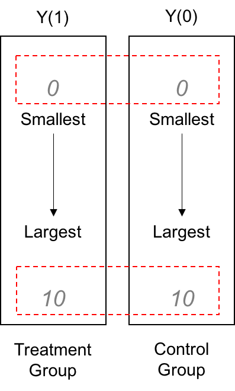

Figure 1: Largest Covariance Estimate

- $\widehat{Cov[Y_i(1),Y_i(0)]}$ is smallest if we pair the smallest $Y_i(1)$ values with the largest $Y_i(0)$ values, and the largest $Y_i(1)$ values with the smallest $Y_i(0)$ values. This can be done if we estimate covariance between outcomes when the control group is arranged in ascending order and the treatment group in descending order. Call this $\widehat{Cov_{min}[Y_i(1),Y_i(0)]}$

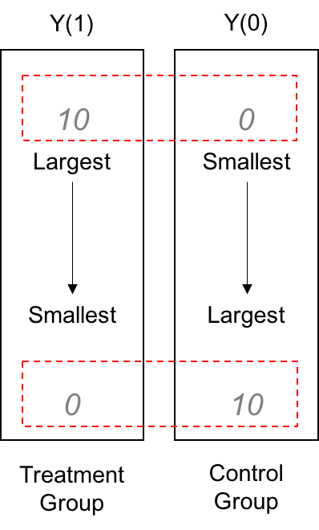

Figure 2: Smallest Covariance Estimate

Then we have two bounds:

Upper bound: $\widehat{Var[Y_i(1)]} + \widehat{Var[Y_i(0)]} - 2\cdot \widehat{Cov_{min}[Y_i(1),Y_i(0)]}$

Lower bound: $\widehat{Var[Y_i(1)]} + \widehat{Var[Y_i(0)]} - 2\cdot \widehat{Cov_{max}[Y_i(1),Y_i(0)]}$

Here is the code to do this in `R`

```r
library(fabricatr)
library(lmtest)
library(ri2)

# Setup: Create some data using 'fabricatr'
set.seed(46)
data <- fabricate(N = 1000, X1 = rnorm(N), X2 = rnorm(N), Y0 = rnorm(N, mean = 0,
    sd = 4) + X1 + X2, Y1 = Y0 + 5, Z = complete_ra(N), Y = Y0 * (1 - Z) + Y1 *
    Z)

kable(head(data), caption = "Example Dataset")
```

Example Dataset

| ID | X1 | X2 | Y0 | Y1 | Z | Y |
| --- | --- | --- | --- | --- | --- | --- |
| 0001 | -0.8989165 | 1.1591073 | -0.5525463 | 4.447454 | 0 | -0.5525463 |
| 0002 | 0.2121311 | 0.5222966 | -3.7698224 | 1.230178 | 1 | 1.2301776 |
| 0003 | -0.7285901 | 1.0230716 | 0.1487505 | 5.148751 | 0 | 0.1487505 |
| 0004 | 1.2355204 | -0.0198303 | 3.1718613 | 8.171861 | 1 | 8.1718613 |
| 0005 | 1.1688400 | 0.5450542 | 2.5888604 | 7.588860 | 1 | 7.5888604 |
| 0006 | -0.6224851 | -1.3212777 | -3.1347933 | 1.865207 | 0 | -3.1347933 |

```r
# Step 0: True Variance in Potential Outcomes (Var[Y1] = Var[Y0] given this
# data generating process)
true.var <- data %>% summarise(VarY0 = var(Y0), VarY1 = var(Y1))
kable(true.var)
```

| VarY0 | VarY1 |
| --- | --- |
| 17.89246 | 17.89246 |

```r
# Step 1: Estimate Var[Y0] and Var[Y1]

var.estimates <- data %>% group_by(Z) %>% summarise(Variance = var(Y))
kable(var.estimates)
```

| Z | Variance |
| --- | --- |
| 0 | 17.78453 |
| 1 | 17.94717 |

```r
var.dif <- var.estimates$Variance[2] - var.estimates$Variance[1]
var.dif
```

```
## [1] 0.1626368
```

```r
# Step 2: Estimate the minimum and maximum values of Cov[Y0,Y1]

control.group <- data %>% filter(Z == 0) %>% arrange(Y)

treat.group.hightolow <- data %>% filter(Z == 1) %>% arrange(desc(Y))
treat.group.lowtohigh <- data %>% filter(Z == 1) %>% arrange(Y)

cov.max <- cov(control.group$Y, treat.group.lowtohigh$Y)
cov.max
```

```
## [1] 17.79711
```

```r
cov.min <- cov(control.group$Y, treat.group.hightolow$Y)
cov.min
```

```
## [1] -17.82733
```

```r
# Step 3: Estimate the upper and lower bound for Var[tau]

var.lower <- var.estimates$Variance[2] + var.estimates$Variance[1] - 2 * cov.max
var.lower
```

```
## [1] 0.1374816
```

```r
var.upper <- var.estimates$Variance[2] + var.estimates$Variance[1] - 2 * cov.min
var.upper
```

```
## [1] 71.38636
```

So we end up with an interval estimate: $Var[\tau_i] \in [0.1374816, 71.38636]$. Note that $Var[\tau_i] \geq 0$, so the minimum value the lower bound can take is 0.

## Difference in Variances

A second way to test for heterogeneity is to evaluate the hypothesis $H_a: \widehat{Var[\tau_i]} \neq 0$. As I will show below, rejecting the hypothesis $Var[Y_i(1)] = Var[Y_i(0)]$ also means rejecting the hypothesis $Var[\tau_i] = 0$. To see this, note that:

$Var[Y_i(1)] = Var[Y_i(0) + \tau_i] = Var[Y_i(0)] + Var[\tau_i] + 2\cdot Cov[Y_i(0),\tau_i]$

Under the constant effects assumption, $Var[\tau_i] = 0$ **and**:

$2 \cdot Cov[Y_i(0), \tau_i] = 0$ because $\tau_i = \tau \forall i$ (i.e. $\tau_i$ is a constant, and the covariance between a random variable and a constant is zero).

This means under the null hypothesis of constant treatment effects:

$Var[Y_i(1)] = Var[Y_i(0)]$ and $Var[Y_i(1)] - Var[Y_i(0)] = 0$

The strategy then is straightforward:

**Step 1**: Estimate the difference in variances or $\widehat{Var[Y_i(1)]} - \widehat{Var[Y_i(0)]}$.

**Step 2**: Assuming constant effects, construct a potential outcomes table. Under this null hypothesis: $Var[\tau_i] = 0$ and $Var[Y_i(1)] = Var[Y_i(0)]$

**Step 3**: Conduct randomization inference to get the $p$ value for the observed difference-in-variance. In other words, the probability of obtaining the observed value or more extreme, given the null hypothesis is correct.

If $p \geq \alpha$ (some arbitrarily selected critical value), we cannot reject the null hypothesis $Var[\tau_i] = 0$ and $Var[Y_i(1)] = Var[Y_i(0)]$. This means we cannot rule out constant treatment effects (or lack of heterogeneity).

Here is `R` code to perform this operation:

```r
# Step 1: Estimate the difference in variances: Var[Y1] - Var[Y0]
var.dif
```

```
## [1] 0.1626368
```

```r
# Step 2: Create a schedule of potential outcomes under the constant
# treatment effects assumption

ate_hat <- lm_robust(Y ~ Z, data = data)$coefficients[2]
ate_hat
```

```
##        Z
## 5.421689
```

```r
ri.data <- data %>% select(Y, Z) %>% mutate(Y0_hyp = Y - ate_hat * Z, Y1_hyp = Y0_hyp +
    ate_hat)
kable(head(ri.data))
```

| Y | Z | Y0_hyp | Y1_hyp |
| --- | --- | --- | --- |
| -0.5525463 | 0 | -0.5525463 | 4.869143 |
| 1.2301776 | 1 | -4.1915118 | 1.230178 |
| 0.1487505 | 0 | 0.1487505 | 5.570440 |
| 8.1718613 | 1 | 2.7501719 | 8.171861 |
| 7.5888604 | 1 | 2.1671710 | 7.588860 |
| -3.1347933 | 0 | -3.1347933 | 2.286896 |

```r
# Step 3A: Specify the random assignment

declaration <- declare_ra(N = 1000, m = 500)

# Step 3B: Write a function that estimates difference in variance

dif_in_var <- function(data) {
    output <- var(data$Y1_hyp[data$Z == 1]) - var(data$Y0_hyp[data$Z == 0])
    return(output)
}

dif_in_var(ri.data)
```

```
## [1] 0.1626368
```

```r
# Step 3C: Conduct randomization inference using 'ri2'

ri.out1 <- conduct_ri(test_function = dif_in_var, assignment = "Z", declaration = declaration,
    data = ri.data, sims = 10000)
summary(ri.out1)
```

```
##             coefficient  estimate two_tailed_p_value null_ci_lower
## 1 Custom Test Statistic 0.1626368             0.9221      -3.16951
##   null_ci_upper
## 1      3.214688
```

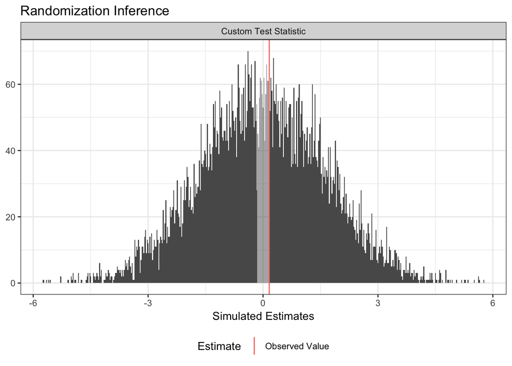

```r
plot(ri.out1)
```

As the hypothesis test reveals, $p = 0.9221$ which suggests a high level of congruence between the null hypothesis ($Var[\tau_i] = 0$ / $Var[Y_i(1)] = Var[Y_i(0)]$) and the observed test statistic ($\widehat{Var[Y_i(1)]} - \widehat{Var[Y_i(0)]}$). We fail to reject the null of constant treatment effects. This is in line with our expectations, given the data generating process specified for this example.

# Interaction Effects

In this part, I discuss regression-based strategies to model treatment effect heterogeneity. I begin with treatment-by-covariate interactions, then move to treatment-by-treatment interactions.

## Treatment-Covariate Interaction

Consider the dataset from the previous section ($n=1000$, $m=500$). Say we are interested in knowing if treatment effects vary by covariate profile (i.e. different levels of $X_1$ and $X_2$). How might we model and estimate that heterogeneity?

**Intution:** Interaction terms in an OLS regression capture heterogeneity in treatment effects. To see this, consider two models:

*Restricted Model:* $Y_i = \alpha_1 + \beta_{1} Z_i + \gamma_{11} X_{1,i} + \gamma_{12} X_{2,i} + u_i$

*Unrestricted Model:* $Y_i = \alpha_2 + \beta_{2} Z_i + \gamma_{21} X_{1,i} + \gamma_{22} X_{2,i} + \gamma_{23} (Z_i \cdot X_{1,i}) + \gamma_{24} (Z_i \cdot X_{2,i}) + \epsilon_i$

We want to know if $\gamma_{23} = \gamma_{24} = 0$, or in words: there is no heterogeneity in treatment effects at different levels of $X_1$ and $X_2$. One way to do this is to estimate the F-statistic (joint significance of the interaction terms), and then do randomization inference to see how likely we are to observe that F-statistic value (or more extreme) if there was no heterogeneity in treatment effects (i.e. under the null hypothesis of constant effects). Here are the steps to do that:

**Step 1:** Estimate the F-statistic

### $F = \frac{\frac{SSR_{R} - SSR_{UR}}{k - q}}{\frac{SSR_{UR}}{N-k}}$

where $k$ is the number of parameters in the unrestricted model (`6`), and $q$ the number of parameters in the restricted model (`4`). Put another way, $k-q$ captures the number of *additional* coefficients whose statistical significance is being evaluated (two interaction terms in this case).

**Step 2:** Generate a full schedule of potential outcomes using $\hat{\beta}$ from the restricted (“base”) model. This schedule is generated under the constant effects assumption.

**Step 3:** Conduct randomization inference to get the distribution of F statistics under the null hypothesis of constant treatment effects. We can then estimate a $p$ value that gives the probability of observing our F-statistic (or more extreme), under the null hypothesis of constant treatment effects.

Here is the `R` code to perform this operation:

```r
# Step 0: Estimate models

model1 <- lm(Y ~ Z + X1 + X2, data = data)
summary(model1)
```

```
##
## Call:
## lm(formula = Y ~ Z + X1 + X2, data = data)
##
## Residuals:
##      Min       1Q   Median       3Q      Max
## -12.6128  -2.5867  -0.0092   2.6175  12.3267
##
## Coefficients:
##             Estimate Std. Error t value Pr(>|t|)
## (Intercept)  -0.1351     0.1818  -0.743    0.458
## Z             5.3212     0.2571  20.693  < 2e-16 ***
## X1            0.8460     0.1253   6.751 2.49e-11 ***
## X2            0.8226     0.1325   6.207 7.92e-10 ***
## ---
## Signif. codes:  0 '***' 0.001 '**' 0.01 '*' 0.05 '.' 0.1 ' ' 1
##
## Residual standard error: 4.061 on 996 degrees of freedom
## Multiple R-squared:  0.3475, Adjusted R-squared:  0.3456
## F-statistic: 176.8 on 3 and 996 DF,  p-value: < 2.2e-16
```

```r
model2 <- lm(Y ~ Z + X1 + X2 + Z * X1 + Z * X2, data = data)

summary(model2)
```

```
##
## Call:
## lm(formula = Y ~ Z + X1 + X2 + Z * X1 + Z * X2, data = data)
##
## Residuals:
##      Min       1Q   Median       3Q      Max
## -12.3455  -2.6071   0.0317   2.5405  12.4775
##
## Coefficients:
##             Estimate Std. Error t value Pr(>|t|)
## (Intercept)  -0.1349     0.1819  -0.742 0.458459
## Z             5.3075     0.2574  20.623  < 2e-16 ***
## X1            0.7518     0.1740   4.321 1.71e-05 ***
## X2            0.6438     0.1872   3.439 0.000609 ***
## Z:X1          0.1908     0.2508   0.761 0.446848
## Z:X2          0.3553     0.2650   1.341 0.180348
## ---
## Signif. codes:  0 '***' 0.001 '**' 0.01 '*' 0.05 '.' 0.1 ' ' 1
##
## Residual standard error: 4.061 on 994 degrees of freedom
## Multiple R-squared:  0.3491, Adjusted R-squared:  0.3458
## F-statistic: 106.6 on 5 and 994 DF,  p-value: < 2.2e-16
```

```r
# Step 1: Perform an F-test (joint significance of interaction terms Z*X1
# and Z*X2)

test.out <- lmtest::waldtest(model1, model2, test = "F")
test.out
```

```
## Wald test
##
## Model 1: Y ~ Z + X1 + X2
## Model 2: Y ~ Z + X1 + X2 + Z * X1 + Z * X2
##   Res.Df Df      F Pr(>F)
## 1    996
## 2    994  2 1.1993 0.3018
```

```r
# Step 2: Randomization Inference to get p value

## Declare the randomization procedure
declaration <- declare_ra(N = 1000, m = 500)

## Create potential outcomes table under the constant treatment effects
## assumption

ate_hat <- model1$coefficients["Z"]
ri.data <- data %>% select(Y, Z, X1, X2) %>% mutate(Y0_hyp = Y - ate_hat * Z,
    Y1_hyp = Y0_hyp + ate_hat)

## Write a function for 'ri2' that computes F statistic

ftest <- function(data) {
    data$Y_sim <- data$Y0_hyp
    data$Y_sim[data$Z == 1] <- data$Y1_hyp[data$Z == 1]
    model1 <- lm(Y_sim ~ Z + X1 + X2, data = data)
    model2 <- lm(Y_sim ~ Z + X1 + X2 + Z * X1 + Z * X2, data = data)
    test.out <- lmtest::waldtest(model1, model2, test = "F")
    test.out$F[2]
}

# Step 3: Randomization inference on ri2

ri.out2 <- conduct_ri(test_function = ftest, assignment = "Z", declaration = declaration,
    data = ri.data, sims = 10000)

summary(ri.out2)
```

```
##             coefficient estimate two_tailed_p_value null_ci_lower
## 1 Custom Test Statistic 1.199303             0.3184    0.02875406
##   null_ci_upper
## 1      3.871089
```

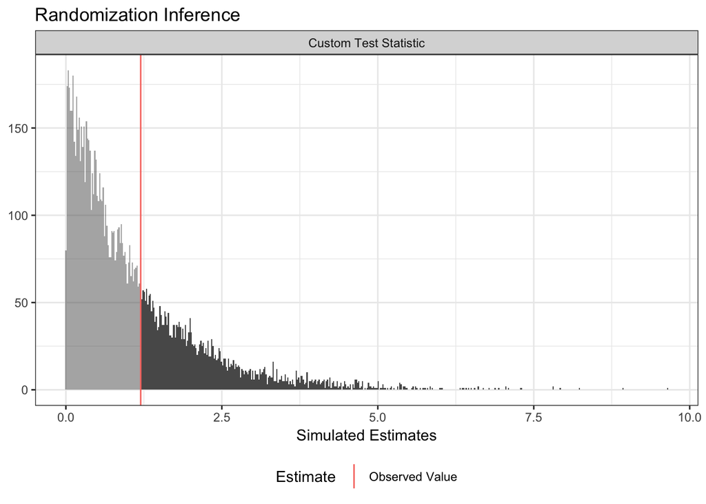

```r
plot(ri.out2)
```

## Treatment-Treatment Interaction

Finally, consider a factorial design in which there are two treatments: $Z_1 \in \{0,1\}$ and $Z_2 \in \{0,1\}$. We are interested in how $Z_1$’s effect varies at different levels of $Z_2$ and vice versa. To do this, consider the following models:

*Restricted Model*: $Y_i = \alpha_1 + \beta_{11} Z_1 + \beta_{12} Z_2 + u_i$

*Unrestricted Model*: $Y_i = \alpha_2 + \beta_{21} Z_1 + \beta_{22} Z_2 + \beta_{23} (Z_1 \cdot Z_2) + \epsilon_i$

We are interested in the interaction term $\beta_{23}$ because it captures the relevant heterogeneity. Visually speaking:

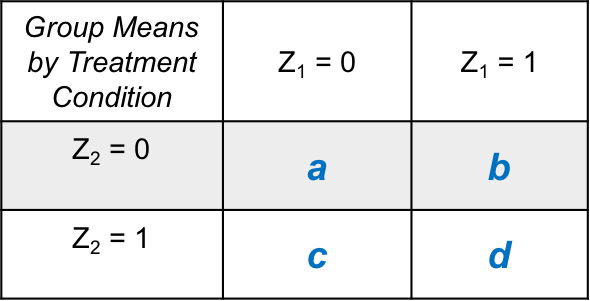

Figure 3: Factorial Design

$\beta_{23} = (d - b) - (c - a)$

Alternatively: $\beta_{23} = (d - c) - (b - a)$

To do randomization inference on $\beta_{23}$, we follow these steps:

- **Step 1:** Estimate the restricted and unrestricted model.
- **Step 2:** Estimate the F statistic, call this `f.obs`.
- **Step 3:** Use the restricted (“base”) model to construct a full schedule of potential outcomes under the constant and additive effects assumption. Note that each observation has four potential outcomes, $Y_i(Z_1,Z_2)$: $Y_{00}$, $Y_{01}$, $Y_{10}$, $Y_{11}$. So we must use $\widehat{\beta_{11}}$ *and* $\widehat{\beta_{12}}$ to generate potential outcomes.
- **Step 4:** Declare the factorial design, and obtain the permutation matrix for randomization inference. (Think of this as a four-arm trial in which units can be assigned with equal probability to `“00”,“01”,“10”,“11”`).
- **Step 5:** For each iteration of the loop, call `Y_sim` the revealed potential outcome of unit $i$, which depends on $i$’s assignment status. Use `Y_sim` to estimate the two models, and the F-statistic. Repeat this process a large number of times to obtain a distribution of F-statistics under the null hypothesis of constant effects. Call this vector `f.stats`
- **Step 6:** Obtain a $p$ value by calculating `mean(abs(f.stats) >= f.obs)`. This is the probability of observing `f.obs` or more extreme under the null hypothesis of constant effects (i.e. no heterogeneity across units or treatment conditions). If $p \leq \alpha$, we can reject the null hypothesis. Put another way, the interaction term is statistically significant.

**Practice:** Lets attempt this by looking at the Rind and Bordia (1996) dataset from Question 6 in this week’s problem set.

```r
data <- foreign::read.dta("W9_RindBordia.dta")

# Step 0: Create treatment indicators
data <- data %>% mutate(Sex = as.numeric(female == "Female"), Face = as.numeric(happyface ==
    "Happy Face"))
head(data)
```

```
##   female happyface   tip xhappy tipround Sex Face
## 1 Female      None 44.78      0       45   1    0
## 2 Female      None 27.55      0       28   1    0
## 3 Female      None 18.12      0       18   1    0
## 4   Male      None  0.00      0        0   0    0
## 5 Female      None 30.08      0       30   1    0
## 6   Male      None 16.28      0       16   0    0
```

```r
# Step 1: Estimate the two models, and joint significance of interaction
# term

model1 <- lm(tip ~ Sex + Face, data = data)

model2 <- lm(tip ~ Sex + Face + Sex * Face, data = data)

# Step 2: Estimate the F-statistic (significance of the interaction term)

test.out <- lmtest::waldtest(model1, model2, test = "F")
test.out  # F= 3.9944
```

```
## Wald test
##
## Model 1: tip ~ Sex + Face
## Model 2: tip ~ Sex + Face + Sex * Face
##   Res.Df Df      F  Pr(>F)
## 1     86
## 2     85  1 3.9944 0.04885 *
## ---
## Signif. codes:  0 '***' 0.001 '**' 0.01 '*' 0.05 '.' 0.1 ' ' 1
```

```r
# Step 3: Construct schedule of potential outcomes under the constant
# effects assumption

ate_hat_sex <- model1$coefficients["Sex"]

ate_hat_face <- model1$coefficients["Face"]

ri.data <- data %>% mutate(Y00 = tip - ate_hat_face * Face - ate_hat_sex * Sex,
    Y10 = Y00 + ate_hat_face * Face, Y01 = Y00 + ate_hat_sex * Sex, Y11 = Y00 +
        ate_hat_face * Face + ate_hat_sex * Sex)

# Step 4: Declare randomization procedure, obtain permutation matrix

declaration = declare_ra(N = nrow(data), prob_each = c(0.25, 0.25, 0.25, 0.25),
    condition_names = c("00", "10", "01", "11"))

perm <- obtain_permutation_matrix(declaration)
dim(perm)
```

```
## [1]    89 10000
```

**Task:** In pairs, write a loop for randomization inference and calculate the two-sided p value for `f.obs` (observed F statistic). Here is what I get:

```
## [1] 0.0474
```

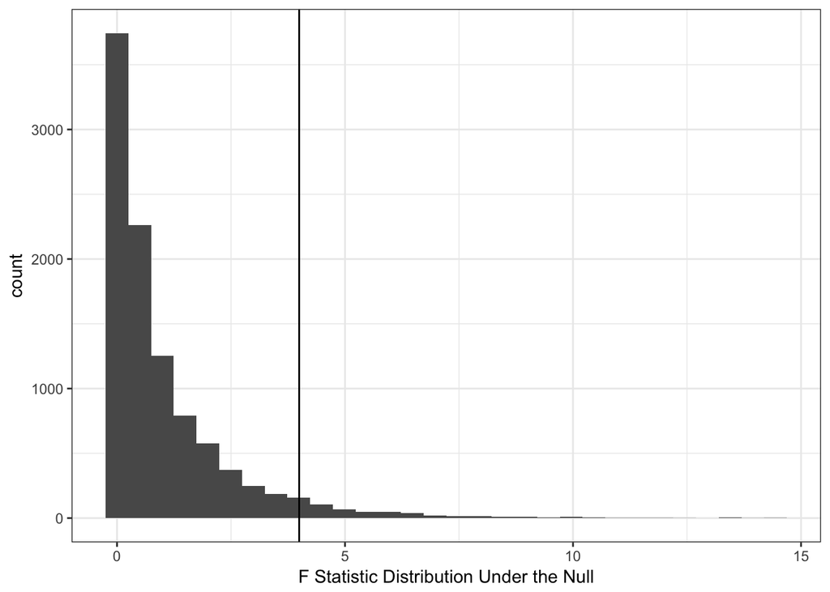